# PhIPSeq_CMV_predictionV2

Sergio Andreu-Sanchez

5/23/2023

# CMV Omics - Script 1: Prediction of CMV seropositivity based on PhIP-Seq profiles.

*R Markdown* of first script. Read data of LLD and IBD cohorts. Use ELISA CMV IgG information from IBD samples to build and compare predictive models. Use the best predictive model on LLD data. Visualize predictions and save dataset for subsequent analyses.

```r
library(tidyverse)
library(readxl)
library(vegan)
library(pheatmap)
library(caret)
library(glmnet)
library(glmnetUtils)
library(MetBrewer)
```

## Read data necessary for running script

Data needed - PhipSeq_covariates.tsv - Immuno_matrix_postSelection.rds : PhIP-Seq profile. Keep IBD and LLD samples - Serology_CMV_IBD_antibodies (1).xlsx : Serology data for IBD cohort - CMV_peptides.tsv : Selection of PhIP-Seq peptides that belong to CMV

```r
Location_dir = "~/Documents/GitHub/CMV_Associations/"


#LLD PhipSeq covariates for both Baseline and Follow-up samples
Covariates_PhipSeq <- read_tsv(paste0(Location_dir, "Data/PhipSeq_covariates.tsv")) #Need to get PhipSeq covariates here, so that I can match with Immuno matrix, predictions,etc

#Phip-Seq enrichment profile matrix. Peptides selection from previous paper --> Includes three cohorts, filter IBD and LLD
immuno_matrix_total <- readRDS(paste0(Location_dir, 'Data/Immuno_matrix_postSelection.rds')) %>% filter(grepl("32_|33_", ID ) )
immuno_matrix_total$ID <- immuno_matrix_total$ID %>% str_replace(".*_", "")

#Serological information
Serology_CMV_IBD_antibodies_1 <- read_excel(paste0(Location_dir,"Data/Serology_CMV_IBD_antibodies (1).xlsx")) %>% drop_na() %>% rename(ID = Sample_id_WIS)
Serology_CMV_IBD_antibodies_1$ID <- Serology_CMV_IBD_antibodies_1$ID %>%  str_replace(".*_", "")

#Selection of Peptides that represent CMV proteins
#cmv_peptides <- colnames(read_csv('Data/CMV for IDs from covariates.csv'))[3:82]
cmv_peptides <- read_tsv(paste0(Location_dir,"Results/CMV_peptides.tsv"))
cmv_peptides <- cmv_peptides$Peptide
#Change to read a list of only CMV peptides
#cmv_peptides = cmv_peptides[! cmv_peptides == "agilent_7061"] #wrong one
immuno_matrix_total %>% select(c("ID", cmv_peptides)) -> cmv_data #There are no NAs
#Match Serology with cmv_data
Serology_CMV_IBD_antibodies_1 %>% select(ID, `CMV-IgG-positivity`) %>% left_join(., cmv_data, by="ID") -> Serology_CMV_IBD_antibodies_2
```

## Prepare and check dataset for prediction

Notes: By checking the heatmap I noticed there was a peptide in the original code that was not from CMV (twist_7061). This shall be removed from the CMV list. To be done: Peptide selection in a previous script –> Check peptides, heatmap, alignment, epitope stats

```r
Serology_CMV_IBD_antibodies_2 %>% group_by(`CMV-IgG-positivity`) %>% summarise(n())
```

```
## # A tibble: 2 × 2
##   `CMV-IgG-positivity` `n()`
##                  <dbl> <int>
## 1                    0   180
## 2                    1   114
```

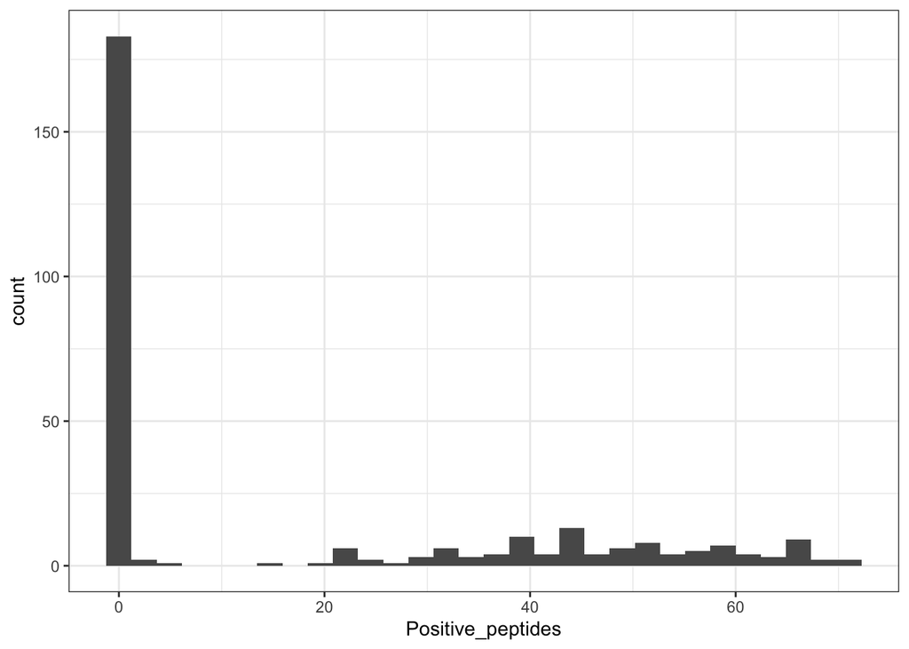

```r
Serology_CMV_IBD_antibodies_2 %>% select(-c(ID,  `CMV-IgG-positivity`)) %>% apply(1, sum) -> Positive_peptides
Serology_CMV_IBD_antibodies_2 %>% mutate(Positive_peptides = Positive_peptides, .before=3 ) -> Serology_CMV_IBD_antibodies_2
#Distribution positive peptides
Serology_CMV_IBD_antibodies_2 %>% ggplot(aes(x = Positive_peptides)) + geom_histogram() + theme_bw()
```

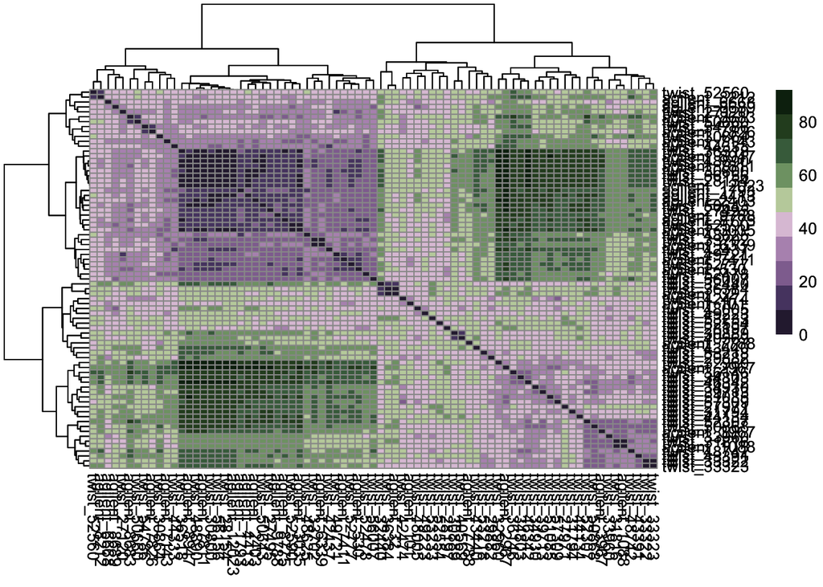

```r
#Relation between peptides
Serology_CMV_IBD_antibodies_2 %>% select(-c(ID,  `CMV-IgG-positivity`,Positive_peptides)) %>% t() %>% vegdist(., method = "manhattan") %>% as.matrix() %>%
  `colnames<-`( colnames(Serology_CMV_IBD_antibodies_2)[4:dim(Serology_CMV_IBD_antibodies_2)[2]] ) %>%  pheatmap(color = met.brewer(name="Cassatt2", type="continuous") ) %>% print()
```

```r
#Twist_7061 is weird. Two big clusters similar among them, different to the other. Check what proteins do each group belong two
```

## Prediction model comparison

We will repeat a K-fold cross-validation procedure N times. Each CV, a new data partition will be performed. Accuracy of prediction on held-out data will be used for unbiased accuracy estimation.

Notes about previous script: Lasso predictions were not between 0-1 (they were logit), thus results were wrong RDA + logistic regression was wrong. It was using the held-out data for both for training and testing

```r
#Setting sed so that partitions will be constant if this code is ran
set.seed(20222)

#Accuracies will be saved in this data frame
Tibble_performances = tibble()

N = 5 #Number of repeptition of the CV
K = 5 #Number of folds to split the data in
Lasso_n = 4 #Number of folds to split the training data  ( (K-1)/K from total data ) for cross-validation to pick up the best hyperparameter lambda (regularization strength)

Serology_CMV_IBD_antibodies_2 %>% mutate(`CMV-IgG-positivity` = as.factor(`CMV-IgG-positivity` ) ) -> Serology_CMV_IBD_antibodies_2
#Repeat cross-validation 5 times
for (Repeat in 1:N){
  print( paste0("Running iteration: ", as.character(Repeat) ) )
  #Split data in folds
  row_folds <- createFolds (1:nrow(Serology_CMV_IBD_antibodies_2), k=K)
  for (i in names(row_folds)){
    #print( paste0("Running: ", i ) )
    select_rows <- row_folds[[i]]
    test <- Serology_CMV_IBD_antibodies_2[select_rows,]
    train <- Serology_CMV_IBD_antibodies_2[-select_rows,]

    ##Model 1: Logistic regression: IgG ~ Number of positive peptides
    logistic_model <- glm(`CMV-IgG-positivity` ~ Positive_peptides, family=binomial(link='logit'), train)
    #predict probabilities
    logistic_probabilities<- predict(logistic_model, newdata=test, type = "response")
    #set threshold
    logistic_predictions = rep(0, dim(test)[1])
    logistic_predictions[logistic_probabilities>.5] = 1
    #determine accuracy
    current_accuracy_logistic<-sum(as.character(logistic_predictions)==as.character(test$`CMV-IgG-positivity`))/length(logistic_predictions)

    rbind(Tibble_performances, tibble( Model="Logistic_with_Sum", Accuracy= current_accuracy_logistic, CV=i, Repetition = Repeat )) -> Tibble_performances

    ##Model 2: Logistic regression with Lasso normalization, using all CMV peptides ##family= binomial => logistic regression, alpha=1 => lasso

    train_lasso<- train %>% dplyr::select(-c("ID","Positive_peptides")) %>% as.data.frame()
    test_lasso <- test %>% dplyr::select(-c("ID","Positive_peptides")) %>% as.data.frame()
    # Find the best lambda using cross-validation.
    #alpha is an hyperparameter that lets you choose between l1 and l2 penalty. An alpha of 1 corresponds to lasso regression
    model_lasso=glmnetUtils::cv.glmnet( `CMV-IgG-positivity` ~., train_lasso, alpha = 1, nfolds = Lasso_n, family = "binomial", type.measure="class", parallel=TRUE)
    # Fit the final model on the training data
    lasso_probabilities = predict(model_lasso, newdata=data.frame(test_lasso %>% select(- `CMV-IgG-positivity`)), type="response", s="lambda.min" )
    lasso_predictions = rep(0, dim(test)[1])
    lasso_predictions[lasso_probabilities>.5] = 1

    current_accuracy_lasso<- sum(as.character(lasso_predictions)==as.character(test_lasso$`CMV-IgG-positivity`))/length(lasso_predictions)

    rbind(Tibble_performances, tibble( Model="Logistic_Lasso", Accuracy= current_accuracy_lasso, CV=i, Repetition = Repeat )) -> Tibble_performances

    ##Model 3: RDA using Serology as independent variable
    #1st find new dimensionality
    Ig = train$`CMV-IgG-positivity`
    Matrix_peptides = select(train, -c(ID, `CMV-IgG-positivity`, Positive_peptides))
    rda(Matrix_peptides ~ Ig) -> PC
    summary(PC)$sites -> PCs
    summary(PC)$species -> sp
    #Predict IG using the new dimensions
    glm(Ig ~ RDA1, as_tibble(PCs) %>% mutate(Ig= as.factor(Ig)) , family = binomial(link="logit"), control = list(maxit = 100, epsilon=1)) -> Model
    #Project test data to new dimensionality ; this projection has correlation 1 with PCs  as.matrix(Matrix_peptides  )  %*% as.matrix(sp)  %>% as_tibble()
    Ig_test <- test$`CMV-IgG-positivity`
    Matrix_test = select(test, -c(ID, `CMV-IgG-positivity`, Positive_peptides))
    as.matrix(Matrix_test) %*% as.matrix(sp) %>% as_tibble() -> Projected_test



    pca_probabilities <-  predict(Model, newdata = dplyr::select(Projected_test, RDA1), type = "response")
    pca_predictions = rep(0, dim(test)[1])
    pca_predictions[pca_probabilities>.5] = 1
    current_pca_accuracy <- sum(as.character(pca_predictions)==as.character(Ig_test))/length(pca_predictions)

    rbind(Tibble_performances, tibble( Model="RDA_Logistic", Accuracy= current_pca_accuracy, CV=i, Repetition = Repeat )) -> Tibble_performances

  }
}
```

```r
#Statistical comparison of mean prediction
aov(Accuracy ~ Model, data = Tibble_performances) %>% TukeyHSD() -> stat.test
print(stat.test)
```

```
##   Tukey multiple comparisons of means
##     95% family-wise confidence level
##
## Fit: aov(formula = Accuracy ~ Model, data = Tibble_performances)
##
## $Model
##                                          diff          lwr         upr
## Logistic_with_Sum-Logistic_Lasso  0.008091585 -0.007870328  0.02405350
## RDA_Logistic-Logistic_Lasso      -0.076883550 -0.092845463 -0.06092164
## RDA_Logistic-Logistic_with_Sum   -0.084975135 -0.100937048 -0.06901322
##                                      p adj
## Logistic_with_Sum-Logistic_Lasso 0.4493453
## RDA_Logistic-Logistic_Lasso      0.0000000
## RDA_Logistic-Logistic_with_Sum   0.0000000
```

```
## $colour
## [1] "CV repetition"
##
## attr(,"class")
## [1] "labels"
```

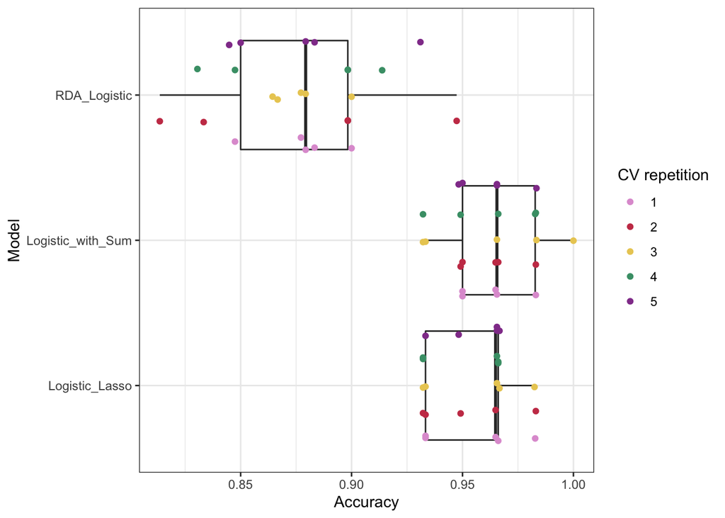

```r
  Tibble_performances %>% ggplot(aes(x=Model, y=Accuracy)) + geom_boxplot() + ggforce::geom_sina(aes(col=as.factor(Repetition))) + theme_bw() + scale_color_discrete(type = met.brewer(name="Klimt", n=5,type="discrete") ) + coord_flip() + labs(color = "CV repetition") %>% print()
```